# SmokingNA-ABMQ

2024-01-29

### Nick’s data - Positive autobiographical memories in cigarette smokers.

- cigarette smokers recalled positive memories in an interview format, for each memory they rated:
  - how long ago the event occurred (ordinal, higher values are more recent memories)
  - if the memory involved cigarette smoking
  - how frequently they think about the memory
  - how (negative-positive) they feel while recalling the memory
  - how vivid the memory is

```r
library("tidyverse")
library("lme4")
mem_init_tib <- read_csv("data/mem_initial_ratings.csv") |> mutate(id = as.character(id))
```

## Hypothesis: In cigarette smokers, the vividness of a memory is related to (a) how old it is, (b) if it involves smoking, and (c) if it is frequently recalled.

#### First let’s look at the vividness ratings (the DV)

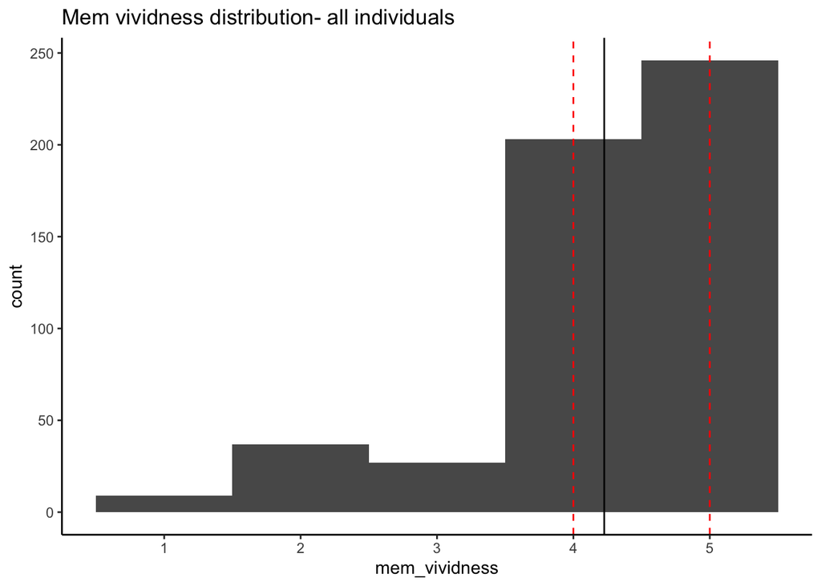

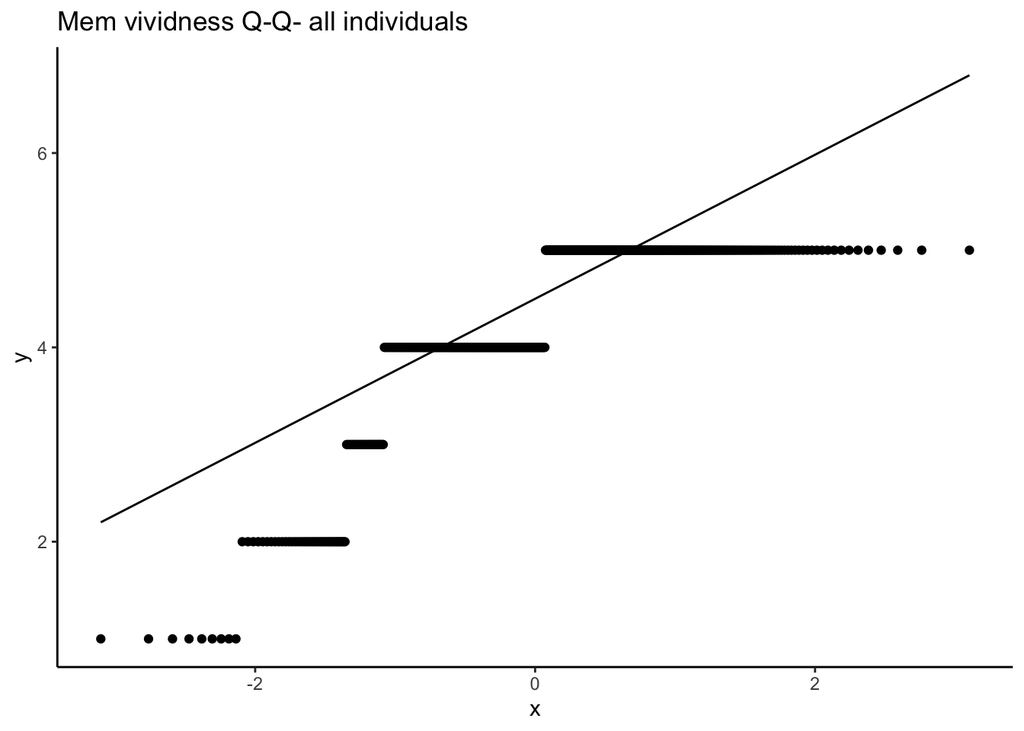

```r
quants <- quantile(mem_init_tib$mem_vividness, c(.25,.5,.75), na.rm = TRUE)
vividness_mean <- mean(mem_init_tib$mem_vividness, na.rm = TRUE)
p1 <- mem_init_tib %>% drop_na(mem_vividness) %>%
  ggplot( aes(x=mem_vividness)) + geom_histogram(binwidth=1) +
    geom_vline(xintercept = quants, colour="red", linetype = "dashed") +
    geom_vline(xintercept = vividness_mean, colour="black") +
    theme_classic() + labs (title = "Mem vividness distribution- all individuals")
p2 <- mem_init_tib %>% drop_na(mem_vividness) %>%
    ggplot( aes(sample=mem_vividness)) + geom_qq() + geom_qq_line() + theme_classic() +
      labs (title = "Mem vividness Q-Q- all individuals")
p1; p2
```

#### Now the time variable (how old is the memory?)

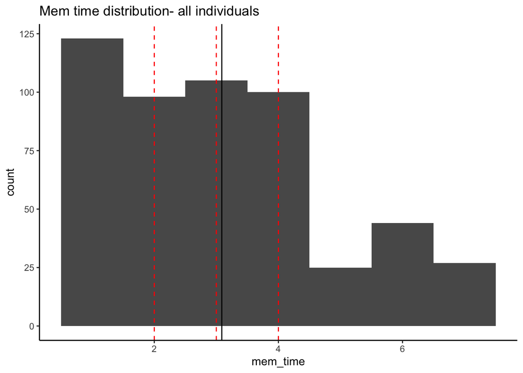

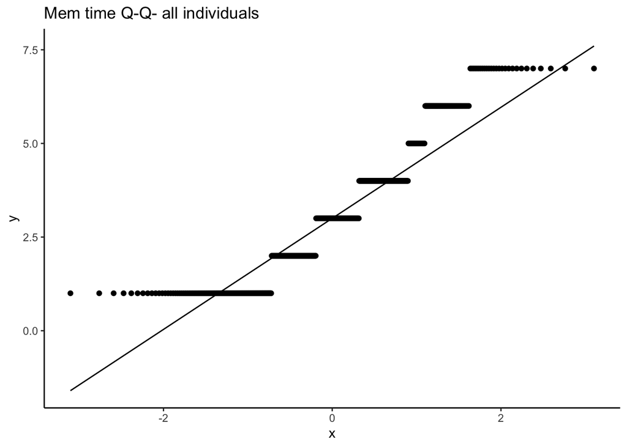

```r
quants <- quantile(mem_init_tib$mem_time, c(.25,.5,.75), na.rm = TRUE)
time_mean <- mean(mem_init_tib$mem_time, na.rm = TRUE)
p1 <- mem_init_tib %>% drop_na(mem_time) %>%
  ggplot( aes(x=mem_time)) + geom_histogram(binwidth=1) +
    geom_vline(xintercept = quants, colour="red", linetype = "dashed") +
    geom_vline(xintercept = time_mean, colour="black") +
    theme_classic() + labs (title = "Mem time distribution- all individuals")
p2 <- mem_init_tib %>% drop_na(mem_time) %>%
    ggplot( aes(sample=mem_time)) + geom_qq() + geom_qq_line() + theme_classic() +
      labs (title = "Mem time Q-Q- all individuals")
p1; p2
```

#### Now the frequency variable (how often do you think about the memory?)

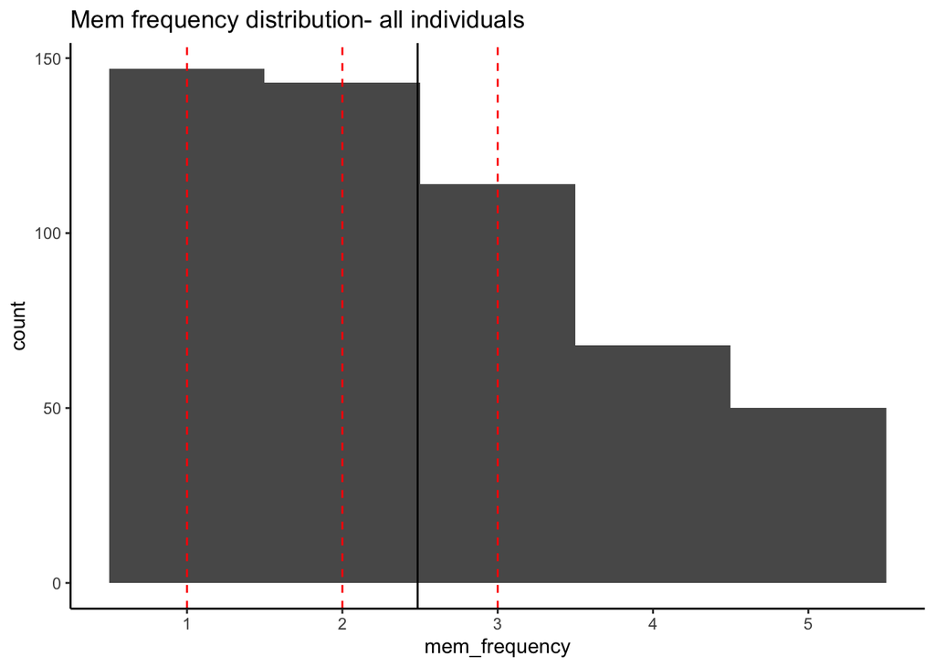

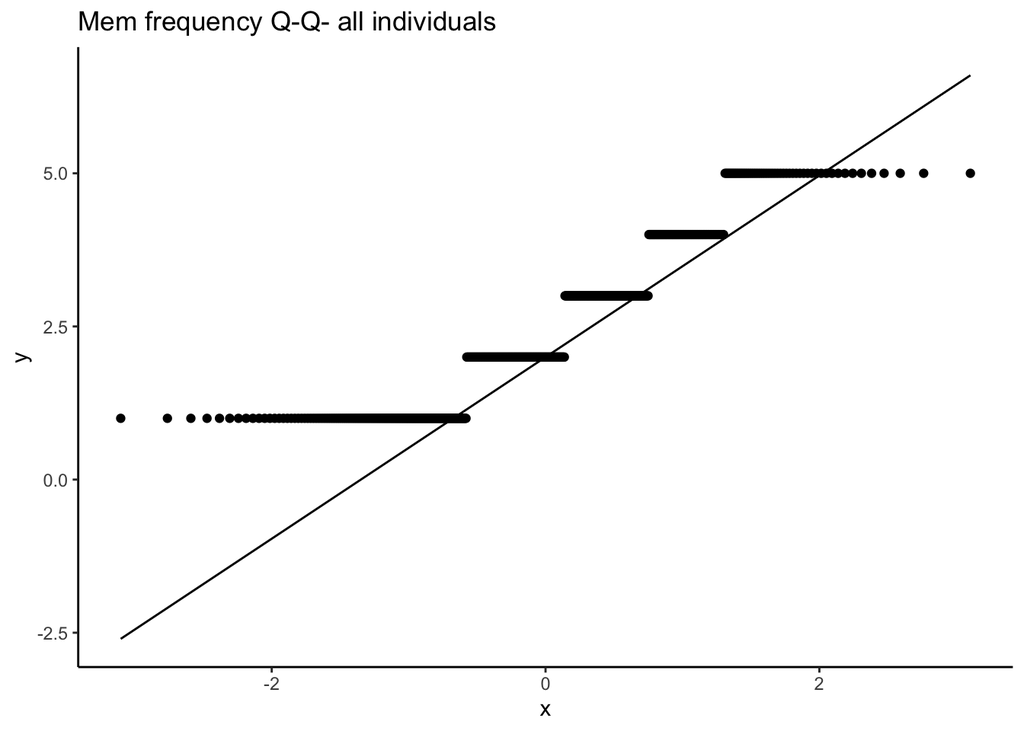

```r
quants <- quantile(mem_init_tib$mem_frequency, c(.25,.5,.75), na.rm = TRUE)
frequency_mean <- mean(mem_init_tib$mem_frequency, na.rm = TRUE)
p1 <- mem_init_tib %>% drop_na(mem_frequency) %>%
  ggplot( aes(x=mem_frequency)) + geom_histogram(binwidth=1) +
    geom_vline(xintercept = quants, colour="red", linetype = "dashed") +
    geom_vline(xintercept = frequency_mean, colour="black") +
    theme_classic() + labs (title = "Mem frequency distribution- all individuals")
p2 <- mem_init_tib %>% drop_na(mem_frequency) %>%
    ggplot( aes(sample=mem_frequency)) + geom_qq() + geom_qq_line() + theme_classic() +
      labs (title = "Mem frequency Q-Q- all individuals")
p1; p2
```